# Factorial Designs

## Two-Way ANOVA

Let’s think more about the two-way ANOVA. The most general model is:

\[y_{ij} = \mu + \alpha_i + \beta_j + (\alpha\beta)_{ij} + \epsilon_{ij}\]

for two factors, \(\alpha\) with \(I\) levels and \(\beta\) with \(J\) levels.

- Note: not all parameters are identifiable.

## Interaction Effects

- Interaction \((\alpha\beta)_{ij}\) is the part of the mean response not attributable to the additive effects of the factors.
  - Ex: you might not want to eat straight sugar or drink heavy cream, but whipped cream (a combination of the two) is much more pleasant.
- Interactions make models harder to interpret, since we can’t examine \(\alpha\) and \(\beta\) independently of each other.

## Interaction Effects

Consider the following 2x2 examples

|  | Male | Female |  | Male | Female |
| --- | --- | --- | --- | --- | --- |
| Drug 1 | 3 | 5 | Drug 1 | 2 | 1 |
| Drug 2 | 1 | 2 | Drug 2 | 1 | 2 |

The response is some measure of drug performance.

## Interaction Effects

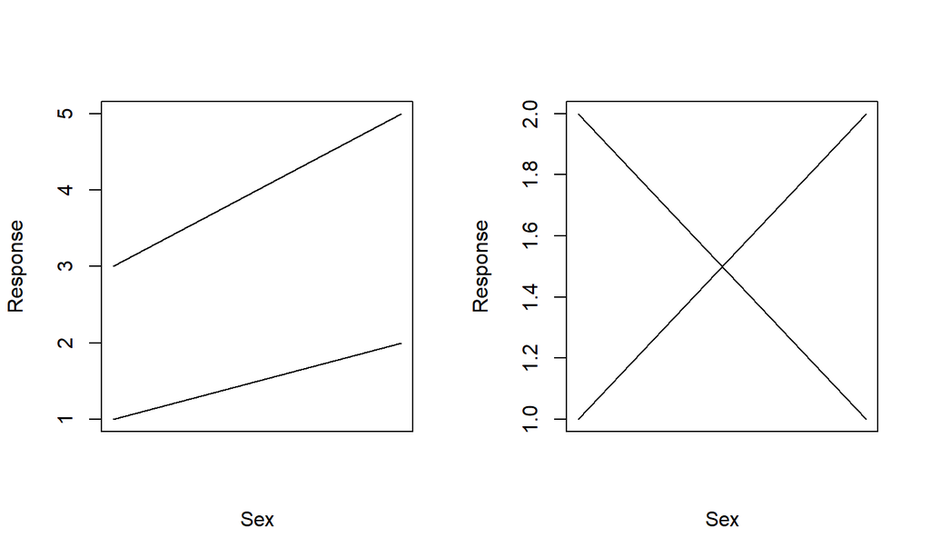

## Interaction Effects

- When there’s an interaction, not a clear way to define the individual effects.
  - Is the gender effect the effect for F? For M? For their average?
- We can also create a model \(y_{ijk}=\mu_{ijk} + \epsilon_{ijk}\), treating it as a one-way ANOVA with \(I\times J\) total levels.

## Two-Way ANOVA with One Observation Per Cell

```r
data("composite")
composite
```

```
##   strength laser   tape
## 1    25.66   40W   slow
## 2    29.15   50W   slow
## 3    35.73   60W   slow
## 4    28.00   40W medium
## 5    35.09   50W medium
## 6    39.56   60W medium
## 7    20.65   40W   fast
## 8    29.79   50W   fast
## 9    35.66   60W   fast
```

## One Observation Per Cell

- One observation for each combination of `laser` and `tape`.

We can fit a main effects model:

```r
mod1 <- lm(strength ~ laser + tape, data=composite)
```

but this loses sight of possible interactions.

However, if we try to fit an interaction model, parameters = observations

## One Observation Per Cell

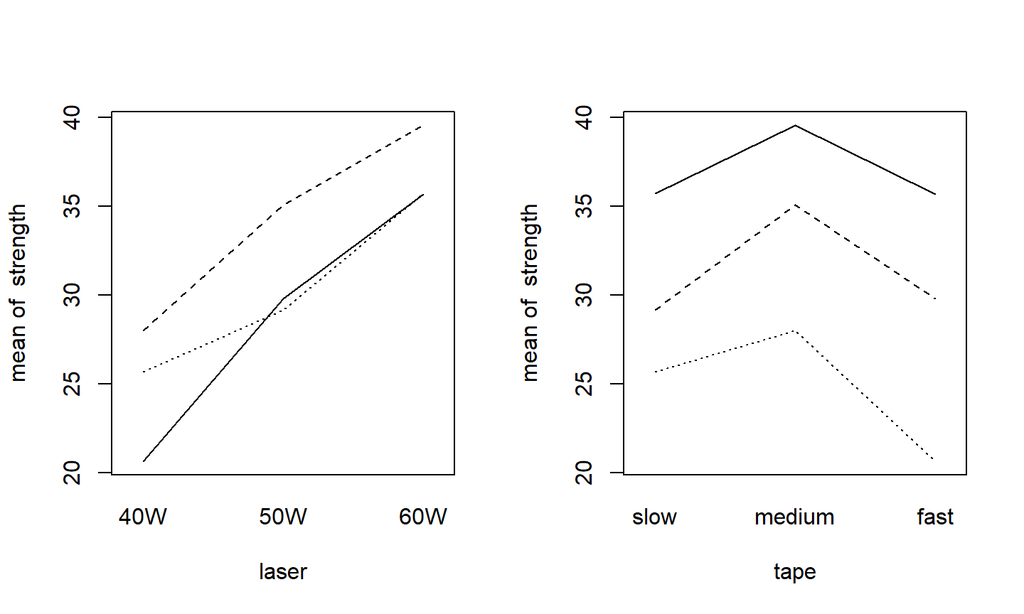

```r
par(mfrow=c(1,2))
with (composite, interaction.plot (laser, tape, strength, legend=F))
with (composite, interaction.plot (tape, laser, strength, legend=F))
```

## Tukey’s Nonadditivity Test

and then test if the interaction term is zero.

- Note that this does assume the interaction is multiplicative, which may not always be the case.

## Tukey’s Nonadditivity Test

```r
coef (mod1)
```

```
## (Intercept)    laser50W    laser60W  tapemedium    tapefast
##   23.917778    6.573333   12.213333    4.036667   -1.480000
```

```r
lasercoefs <- rep(c(0,6.5733, 12.2133),3)
tapecoefs <- rep(c(0,4.0367,-1.4800), each=3)
h <- update(mod1, . ~ . + I(lasercoefs*tapecoefs))
```

## Tukey’s Nonadditivity Test

```r
anova(h)
```

```
## Analysis of Variance Table
##
## Response: strength
##                           Df  Sum Sq Mean Sq F value   Pr(>F)
## laser                      2 224.184 112.092 36.8201 0.007745 **
## tape                       2  48.919  24.459  8.0344 0.062401 .
## I(lasercoefs * tapecoefs)  1   1.370   1.370  0.4501 0.550340
## Residuals                  3   9.133   3.044
## ---
## Signif. codes:  0 '***' 0.001 '**' 0.01 '*' 0.05 '.' 0.1 ' ' 1
```

Looks like the interaction is not significant

## One Observation Per Cell

```r
anova(mod1)
```

```
## Analysis of Variance Table
##
## Response: strength
##           Df  Sum Sq Mean Sq F value   Pr(>F)
## laser      2 224.184 112.092 42.6893 0.002003 **
## tape       2  48.919  24.459  9.3151 0.031242 *
## Residuals  4  10.503   2.626
## ---
## Signif. codes:  0 '***' 0.001 '**' 0.01 '*' 0.05 '.' 0.1 ' ' 1
```

We can then look at the plots and coefficients to see how strength changes with laser power and tape speed.

## One Observation Per Cell

One thing we’re not taking into account is that these factors are *ordered*.

```r
composite$laser <- as.ordered(composite$laser)
composite$tape <- as.ordered(composite$tape)
g <- lm(strength ~ laser + tape, composite)
summary(g) #note the anova itself will look the same
```

`Estimate Std. Error t value Pr(>|t|)`

`(Intercept) 31.0322 0.5401 57.452 5.5e-07 ***`

`laser.L 8.6361 0.9355 9.231 0.000765 ***`

`laser.Q -0.3810 0.9355 -0.407 0.704655`

`tape.L -1.0465 0.9355 -1.119 0.325944`

`tape.Q -3.9001 0.9355 -4.169 0.014045 *`

`Multiple R-squared: 0.963, Adjusted R-squared: 0.9259`

`F-statistic: 26 on 4 and 4 DF, p-value: 0.004013`

## Two-Way ANOVA

Two-way ANOVA with more than one observation per cell:

Consider the setting where \(n_{ij}=n>1\) for all \(i,j\).

- We call this design *orthogonal*

Our model \[y_{ij} = \mu + \alpha_i + \beta_j + (\alpha\beta)_{ij} + \epsilon_{ij}\] is now identifiable and can be examined in the usual ways.

## Two-Way ANOVA

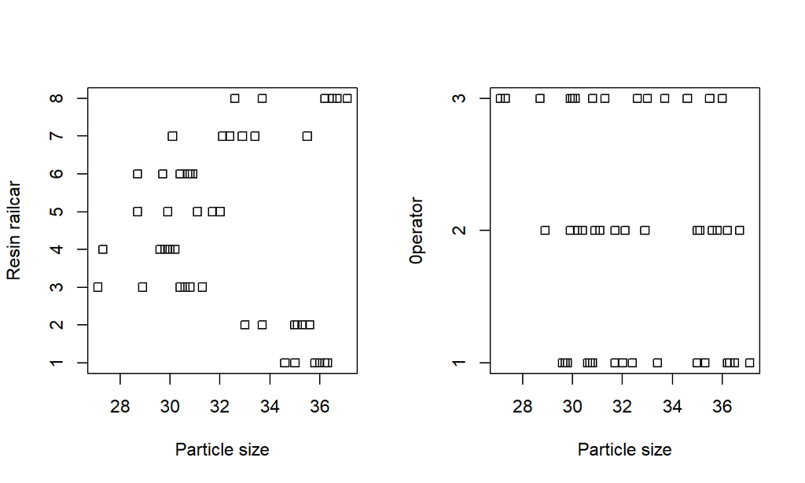

```r
data(pvc); attach(pvc)
par(mfrow=c(1,2))
stripchart (psize ~ resin, xlab="Particle size", ylab="Resin railcar")
stripchart (psize ~ operator, xlab="Particle size", ylab="0perator")
```

## Two-Way ANOVA

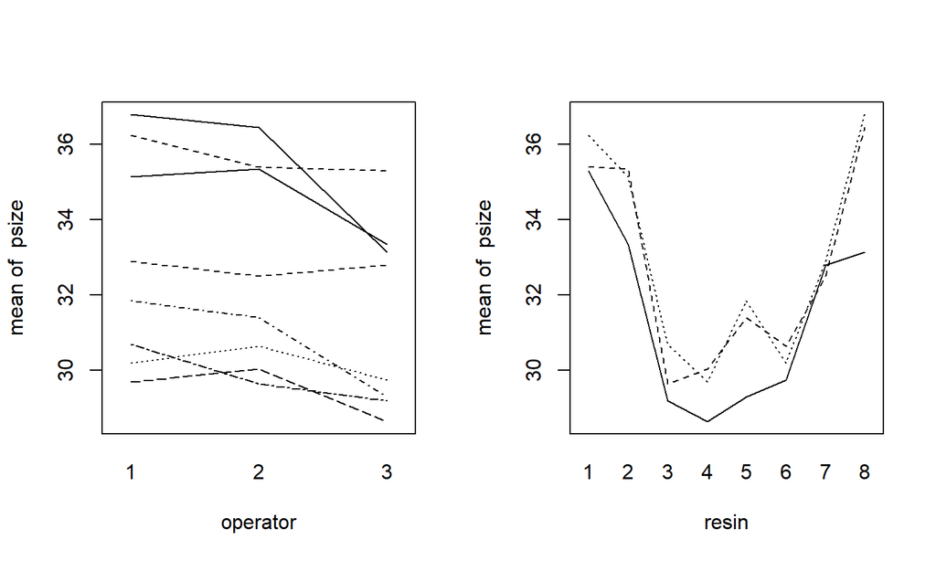

Can be hard to tell random noise vs. actual interactions.

## Two-Way ANOVA

```r
mod2 <- lm(psize ~ operator*resin, pvc)
anova(mod2)
```

```
## Analysis of Variance Table
##
## Response: psize
##                Df  Sum Sq Mean Sq F value    Pr(>F)
## operator        2  20.718  10.359  7.0072   0.00401 **
## resin           7 283.946  40.564 27.4388 5.661e-10 ***
## operator:resin 14  14.335   1.024  0.6926   0.75987
## Residuals      24  35.480   1.478
## ---
## Signif. codes:  0 '***' 0.001 '**' 0.01 '*' 0.05 '.' 0.1 ' ' 1
```

## Two-Way ANOVA

```r
anova(lm(psize ~ operator+resin, pvc))
```

```
## Analysis of Variance Table
##
## Response: psize
##           Df  Sum Sq Mean Sq F value    Pr(>F)
## operator   2  20.718  10.359   7.902   0.00135 **
## resin      7 283.946  40.564  30.943 8.111e-14 ***
## Residuals 38  49.815   1.311
## ---
## Signif. codes:  0 '***' 0.001 '**' 0.01 '*' 0.05 '.' 0.1 ' ' 1
```

## ANOVA Diagnostics

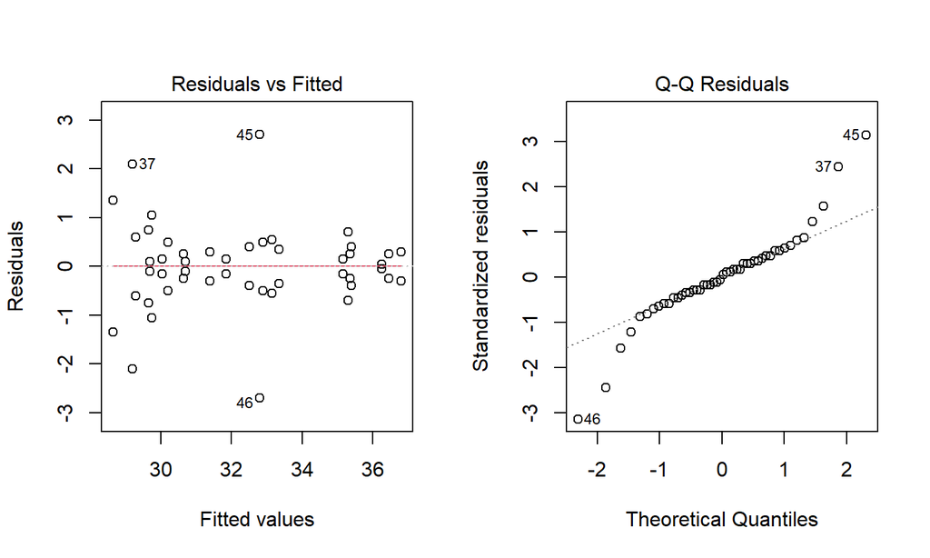

```r
par(mfrow=c(1,2))
plot(mod2, which=c(2,1))
```

## ANOVA Diagnostics

- Some evidence of outliers.
- Symmetry is because, for the full model, the fitted value for each combination of factors is the mean of the two replicates.

## ANOVA Diagnostics

```r
mod4 <- lm(psize ~ operator+resin, pvc[-45,]) # remove outlier
anova(mod4)
```

```
## Analysis of Variance Table
##
## Response: psize
##           Df  Sum Sq Mean Sq F value    Pr(>F)
## operator   2  28.215  14.108  15.973 9.982e-06 ***
## resin      7 283.479  40.497  45.853 2.497e-16 ***
## Residuals 37  32.678   0.883
## ---
## Signif. codes:  0 '***' 0.001 '**' 0.01 '*' 0.05 '.' 0.1 ' ' 1
```

## Pairwise Comparisons

```r
TukeyHSD(aov(mod4))
```

```
##   Tukey multiple comparisons of means
##     95% family-wise confidence level
##
## Fit: aov(formula = mod4)
##
## $operator
##          diff       lwr        upr     p adj
## 2-1 -0.262500 -1.073718  0.5487178 0.7114176
## 3-1 -1.777083 -2.601711 -0.9524561 0.0000184
## 3-2 -1.514583 -2.339211 -0.6899561 0.0001985
##
## $resin
##           diff         lwr        upr     p adj
## 2-1 -1.0333333 -2.77520402  0.7085374 0.5566387
## 3-1 -5.8000000 -7.54187069 -4.0581293 0.0000000
## 4-1 -6.1833333 -7.92520402 -4.4414626 0.0000000
## 5-1 -4.8000000 -6.54187069 -3.0581293 0.0000000
## 6-1 -5.4500000 -7.19187069 -3.7081293 0.0000000
## 7-1 -3.6894444 -5.51633383 -1.8625551 0.0000037
## 8-1 -0.1833333 -1.92520402  1.5585374 0.9999706
## 3-2 -4.7666667 -6.50853735 -3.0247960 0.0000000
## 4-2 -5.1500000 -6.89187069 -3.4081293 0.0000000
## 5-2 -3.7666667 -5.50853735 -2.0247960 0.0000009
## 6-2 -4.4166667 -6.15853735 -2.6747960 0.0000000
## 7-2 -2.6561111 -4.48300050 -0.8292217 0.0009360
## 8-2  0.8500000 -0.89187069  2.5918707 0.7663296
## 4-3 -0.3833333 -2.12520402  1.3585374 0.9962814
## 5-3  1.0000000 -0.74187069  2.7418707 0.5962925
## 6-3  0.3500000 -1.39187069  2.0918707 0.9978942
## 7-3  2.1105556  0.28366617  3.9374449 0.0141248
## 8-3  5.6166667  3.87479598  7.3585374 0.0000000
## 5-4  1.3833333 -0.35853735  3.1252040 0.2072051
## 6-4  0.7333333 -1.00853735  2.4752040 0.8725789
## 7-4  2.4938889  0.66699950  4.3207783 0.0021575
## 8-4  6.0000000  4.25812931  7.7418707 0.0000000
## 6-5 -0.6500000 -2.39187069  1.0918707 0.9274222
## 7-5  1.1105556 -0.71633383  2.9374449 0.5263790
## 8-5  4.6166667  2.87479598  6.3585374 0.0000000
## 7-6  1.7605556 -0.06633383  3.5874449 0.0658042
## 8-6  5.2666667  3.52479598  7.0085374 0.0000000
## 8-7  3.5061111  1.67922172  5.3330005 0.0000099
```

## A Few Notes

- The factors in these models are *fixed effects*.
  - If factors were randomly selected from larger population, they would be *random effects*, which are a little more complicated to deal with.
- Also important that observations be genuine replications.
  - If they are correlated, the analysis will need to be adjusted.
  - Repeated measurements are *not* replications and will be correlated.
    - Repeated measures ANOVA, etc.

## Larger Factorial Experiments

Suppose we have three or more factors \(\alpha, \beta, \gamma, \dots\) each with some number of levels \(l_{\alpha}, l_{\beta}, l_{\gamma}, \dots\).

- A *full factorial* experiment has at least one run for each combination of factor levels (equal to \(l_{\alpha}\times l_{\beta}\times l_{\gamma}\times\dots\))
  - This can easily be a very large number of treatments!
  - Could also include all possible interactions, higher order terms, etc.
  - Usually not performed for more than three or four factors.

## Larger Factorial Experiments

- If no interactions significant, we get several one-way experiments for the cost of one.
- Efficient with experimental resources.
- Often done without replication due to cost concerns.
  - May need to assume some higher order interactions are zero in order to have enough degrees of freedom to examine lower level effects.

## Fractional Factorials

- Use only a fraction of the number of runs done in a full factorial experiment.

Consider an experiment with 7 factors, each with 2 levels:

| Effect | mean | main | 2-way | 3-way | 4 | 5 | 6 | 7 |
| --- | --- | --- | --- | --- | --- | --- | --- | --- |
| Parameters | 1 | 7 | 21 | 35 | 35 | 21 | 7 | 1 |

- Assuming higher order interactions are negligible will save us from doing \(2^7=128\) runs.
- 8 runs would allow us to estimate main effects.
- Hard to find a good design to examine all 2-way effects without a lot of runs.

## Fractional Factorials

Goal: estimate as many parameters as possible with as few data points as possible.

- May not have many degrees of freedom left over.
- \(\sigma^2\) must be small for this to work (to distinguish significant effects).

## Example

```r
data(speedo)
speedo # two levels of each factor: +/-
```

```
##    h d l b j f n a i e m c k g o      y
## 1  - - + - + + - - + + - + - - + 0.4850
## 2  + - - - - + + - - + + + + - - 0.5750
## 3  - + - - + - + - + - + + - + - 0.0875
## 4  + + + - - - - - - - - + + + + 0.1750
## 5  - - + + - - + - + + - - + + - 0.1950
## 6  + - - + + - - - - + + - - + + 0.1450
## 7  - + - + - + - - + - + - + - + 0.2250
## 8  + + + + + + + - - - - - - - - 0.1750
## 9  - - + - + + - + - - + - + + - 0.1250
## 10 + - - - - + + + + - - - - + + 0.1200
## 11 - + - - + - + + - + - - + - + 0.4550
## 12 + + + - - - - + + + + - - - - 0.5350
## 13 - - + + - - + + - - + + - - + 0.1700
## 14 + - - + + - - + + - - + + - - 0.2750
## 15 - + - + - + - + - + - + - + - 0.3425
## 16 + + + + + + + + + + + + + + + 0.5825
```

```r
mod5 <- lm(y ~ ., speedo)
summary(mod5) # all residuals are 0!
```

```
##
## Call:
## lm(formula = y ~ ., data = speedo)
##
## Residuals:
## ALL 16 residuals are 0: no residual degrees of freedom!
##
## Coefficients:
##               Estimate Std. Error t value Pr(>|t|)
## (Intercept)  0.5825000        NaN     NaN      NaN
## h-          -0.0621875        NaN     NaN      NaN
## d-          -0.0609375        NaN     NaN      NaN
## l-          -0.0271875        NaN     NaN      NaN
## b-           0.0559375        NaN     NaN      NaN
## j-           0.0009375        NaN     NaN      NaN
## f-          -0.0740625        NaN     NaN      NaN
## n-          -0.0065625        NaN     NaN      NaN
## a-          -0.0678125        NaN     NaN      NaN
## i-          -0.0428125        NaN     NaN      NaN
## e-          -0.2453125        NaN     NaN      NaN
## m-          -0.0278125        NaN     NaN      NaN
## c-          -0.0896875        NaN     NaN      NaN
## k-          -0.0684375        NaN     NaN      NaN
## g-           0.1403125        NaN     NaN      NaN
## o-          -0.0059375        NaN     NaN      NaN
##
## Residual standard error: NaN on 0 degrees of freedom
## Multiple R-squared:      1,  Adjusted R-squared:    NaN
## F-statistic:   NaN on 15 and 0 DF,  p-value: NA
```

## Example

We have no degrees of freedom, as number cases = number parameters.

```r
model.matrix(mod5) # + is coded as 0; - as 1 bx of ASCII alphabet
```

```
##    (Intercept) h- d- l- b- j- f- n- a- i- e- m- c- k- g- o-
## 1            1  1  1  0  1  0  0  1  1  0  0  1  0  1  1  0
## 2            1  0  1  1  1  1  0  0  1  1  0  0  0  0  1  1
## 3            1  1  0  1  1  0  1  0  1  0  1  0  0  1  0  1
## 4            1  0  0  0  1  1  1  1  1  1  1  1  0  0  0  0
## 5            1  1  1  0  0  1  1  0  1  0  0  1  1  0  0  1
## 6            1  0  1  1  0  0  1  1  1  1  0  0  1  1  0  0
## 7            1  1  0  1  0  1  0  1  1  0  1  0  1  0  1  0
## 8            1  0  0  0  0  0  0  0  1  1  1  1  1  1  1  1
## 9            1  1  1  0  1  0  0  1  0  1  1  0  1  0  0  1
## 10           1  0  1  1  1  1  0  0  0  0  1  1  1  1  0  0
## 11           1  1  0  1  1  0  1  0  0  1  0  1  1  0  1  0
## 12           1  0  0  0  1  1  1  1  0  0  0  0  1  1  1  1
## 13           1  1  1  0  0  1  1  0  0  1  1  0  0  1  1  0
## 14           1  0  1  1  0  0  1  1  0  0  1  1  0  0  1  1
## 15           1  1  0  1  0  1  0  1  0  1  0  1  0  1  0  1
## 16           1  0  0  0  0  0  0  0  0  0  0  0  0  0  0  0
## attr(,"assign")
##  [1]  0  1  2  3  4  5  6  7  8  9 10 11 12 13 14 15
## attr(,"contrasts")
## attr(,"contrasts")$h
## [1] "contr.treatment"
##
## attr(,"contrasts")$d
## [1] "contr.treatment"
##
## attr(,"contrasts")$l
## [1] "contr.treatment"
##
## attr(,"contrasts")$b
## [1] "contr.treatment"
##
## attr(,"contrasts")$j
## [1] "contr.treatment"
##
## attr(,"contrasts")$f
## [1] "contr.treatment"
##
## attr(,"contrasts")$n
## [1] "contr.treatment"
```

[output cut: 9 more lines]

[output not shown]

## Example

Can’t do usual F-tests, so need different approach.

- Suppose no significant effects and errors normally distributed.
  - Estimated effects would be linear combos of errors and so also normal.
  - We can make a normal QQ plot of main effects.
    - Idea: outliers represent something interesting happening (significant effects).

## Example

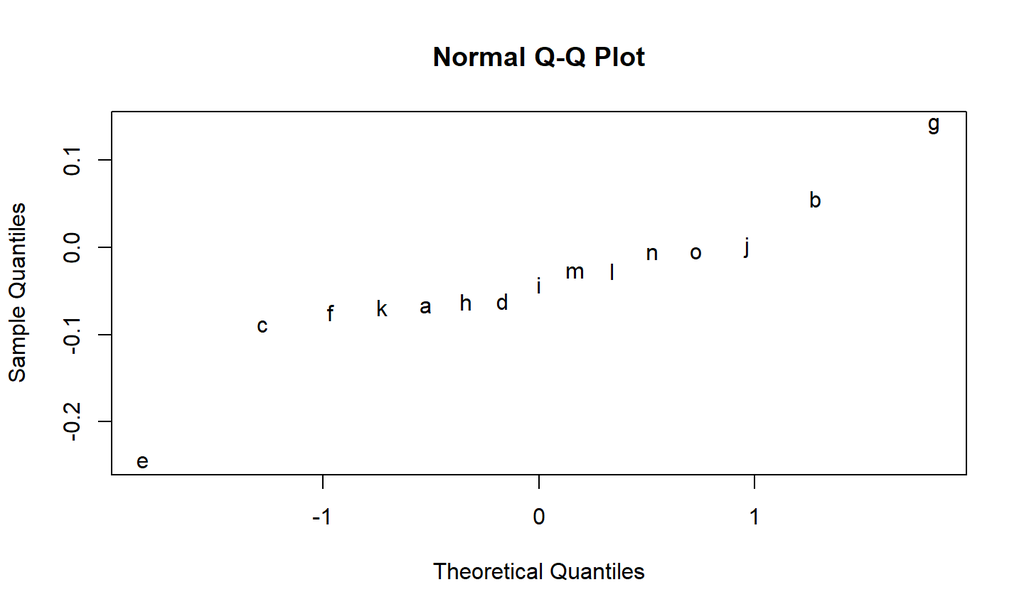

```r
qqnorm(coef(mod5)[-1], pch=names(coef(mod5)[-1]))
```

## Example

So we might further examine effects of `e` and `g`.